# Tecator

Ra’Shawn Howard

# Data Description

Infrared (IR) spectroscopy technology is used to determine the chemical makeup of a substance. The device measures the absorbance of the sample at each individual frequency. This series of measurements creates a spectrum profile which can then be used to determine the chemical makeup of the sample material. A Tecator Infratec Food and Feed Analyzer intrument was used to analyze 215 samples of meat across 100 frequencies. In addition to an IR profile, analytical chemistry determined the percent fat for each sample.

# Goals of Analysis

# Methodology

The data was split into a testing and training set, and different preprocessing methods were done.  
The predictors are highly correlated, so PCA was used to reduce the dimension of the predictor space.  
Cross-validation was done to find the optimal value of the tuning parameters for models that required this.  
The different types of models that fit the data were: bagged trees, boosted trees, cubist, linear regression, decision trees, MARS, neural networks, KNN, random forest, and SVM.  
The neural network model performed the best on the training data with an RMSE of .85088724 and a standard error of 0.03248912, followed by the cubist model.

| percent_moister | fat | protein |
| --- | --- | --- |
| 60.50 | 22.5 | 16.7 |
| 46.00 | 40.1 | 13.5 |
| 71.00 | 8.4 | 20.5 |
| 72.80 | 5.9 | 20.7 |
| 58.30 | 25.5 | 15.5 |
| 44.00 | 42.7 | 13.7 |
| 44.00 | 42.7 | 13.7 |
| 69.30 | 10.6 | 19.3 |
| 61.40 | 19.9 | 17.7 |
| 61.40 | 19.9 | 17.7 |

[output cut: 205 more lines]

# EDA

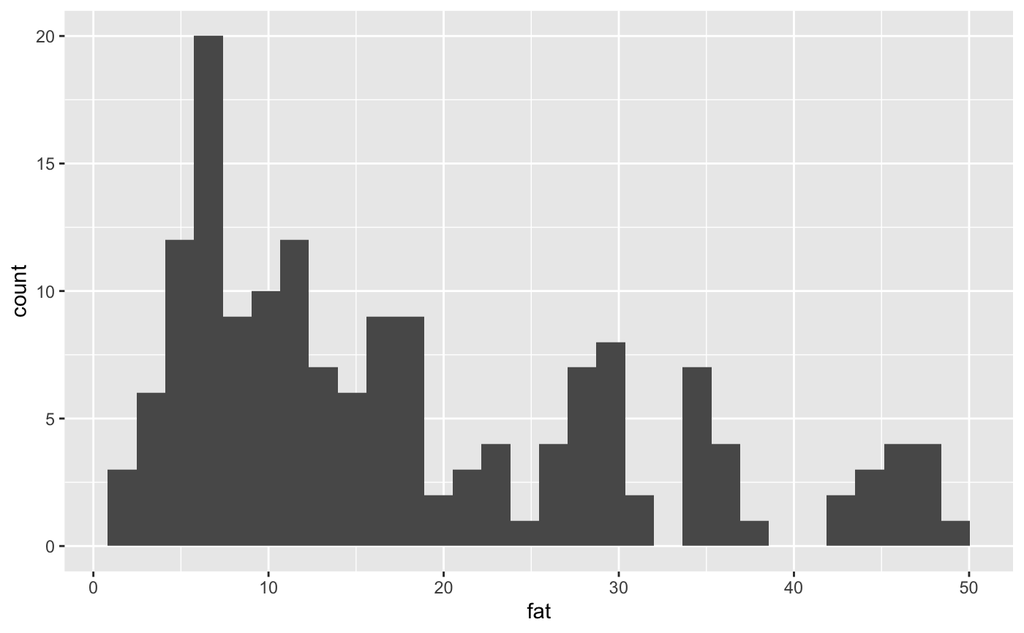

# Linear Models

## Pre-Processing

```r
rec_pls <- recipe(fat~., data = train) %>%
  step_BoxCox(all_numeric_predictors()) %>%
  step_center(all_numeric_predictors()) %>%
  step_scale(all_numeric_predictors()) %>%
  step_pls(all_numeric_predictors())
```

[output not shown]

## Resamples

```r
grid <- grid_regular(finalize(num_comp("pca"),train), levels = 50)
```

[output not shown]

## Linear Model Specifications

```r
lm_spec <- linear_reg() %>%
  set_engine("lm")

ridge_spec <- linear_reg(mixture = 0, penalty = tune()) %>%
  set_engine("glmnet") %>%
  set_mode("regression")

lasso_spec <- linear_reg(mixture = 1, penalty = tune()) %>%
  set_engine("glmnet") %>%
  set_mode("regression")

ennet_spec <- linear_reg(mixture = tune(), penalty = tune()) %>%
  set_engine("glmnet") %>%
  set_mode("regression")
```

```r
library(plot3D)

rec_pca %>%
  prep() %>%
  juice() -> temp_pca_data

x <- temp_pca_data$PC1
y <- temp_pca_data$PC2
z <- temp_pca_data$fat

lin_mod <- lm(z~x+y)

grid.lines = 40
x.pred <- seq(min(x), max(x), length.out = grid.lines)
y.pred <- seq(min(y), max(y), length.out = grid.lines)
xy <- expand.grid( x = x.pred, y = y.pred)
z.pred <- matrix(predict(lin_mod, newdata = xy),
                 nrow = grid.lines, ncol = grid.lines)

fitpoints <- predict(lin_mod)

scatter3D(x, y, z, pch = 19, cex = 1,colvar = NULL, col="red",
          theta = 10, phi = 30, bty="b",
          xlab = "PC1", ylab = "PC2", zlab = "Fat",
          surf = list(x = x.pred, y = y.pred, z = z.pred,
                      facets = TRUE, fit = fitpoints, col=ramp.col (col = c("dodgerblue3","seagreen2"), n = 300, alpha=0.9),
                      border="black"), main = "Fat Prediction Using PCA")
```

[output not shown]

```r
lm_models <- workflow_set(preproc, models = list(lm = lm_spec,
                                        ridge = ridge_spec,
                                        lasso = lasso_spec,
                                        net = ennet_spec), cross = TRUE)
```

[output not shown]

```r
lm_models <- lm_models %>%
  workflow_map("tune_grid",
             seed = 1101, verbose = TRUE,
             resamples = folds, grid = 20)
```

| wflow_id | .config | .metric | mean | std_err | n | preprocessor | model | rank |
| --- | --- | --- | --- | --- | --- | --- | --- | --- |
| recipe_net | Preprocessor1_Model03 | rmse | 3.3251966 | 0.069383093 | 25 | recipe | linear_reg | 1 |
| recipe_net | Preprocessor1_Model03 | rsq | 0.9392922 | 0.002908652 | 25 | recipe | linear_reg | 1 |
| recipe_net | Preprocessor1_Model02 | rmse | 3.3335045 | 0.068216757 | 25 | recipe | linear_reg | 2 |
| recipe_net | Preprocessor1_Model02 | rsq | 0.9388037 | 0.002917641 | 25 | recipe | linear_reg | 2 |
| recipe_net | Preprocessor1_Model04 | rmse | 3.3500237 | 0.073199390 | 25 | recipe | linear_reg | 3 |
| recipe_net | Preprocessor1_Model04 | rsq | 0.9376406 | 0.004111213 | 25 | recipe | linear_reg | 3 |
| recipe_net | Preprocessor1_Model01 | rmse | 3.3734363 | 0.070629668 | 25 | recipe | linear_reg | 4 |
| recipe_net | Preprocessor1_Model01 | rsq | 0.9367246 | 0.003324268 | 25 | recipe | linear_reg | 4 |
| recipe_net | Preprocessor1_Model07 | rmse | 3.4271606 | 0.090234789 | 25 | recipe | linear_reg | 5 |
| recipe_net | Preprocessor1_Model07 | rsq | 0.9346762 | 0.004372625 | 25 | recipe | linear_reg | 5 |

[output cut: 112 more lines]

# Nonlinear Models

## Non-linear Model Specs

| wflow_id | .config | .metric | mean | std_err | n | preprocessor | model | rank |
| --- | --- | --- | --- | --- | --- | --- | --- | --- |
| recipe_1_mlp | Preprocessor1_Model07 | rmse | 0.85088724 | 3.248912e-02 | 25 | recipe | mlp | 1 |
| recipe_1_mlp | Preprocessor1_Model07 | rsq | 0.99540691 | 4.187456e-04 | 25 | recipe | mlp | 1 |
| recipe_1_mlp | Preprocessor1_Model01 | rmse | 0.90766128 | 4.679322e-02 | 25 | recipe | mlp | 2 |
| recipe_1_mlp | Preprocessor1_Model01 | rsq | 0.99453807 | 8.368555e-04 | 25 | recipe | mlp | 2 |
| recipe_1_mlp | Preprocessor1_Model12 | rmse | 0.95995023 | 7.313410e-02 | 25 | recipe | mlp | 3 |
| recipe_1_mlp | Preprocessor1_Model12 | rsq | 0.99324809 | 1.630474e-03 | 25 | recipe | mlp | 3 |
| recipe_1_mlp | Preprocessor1_Model20 | rmse | 1.12470174 | 1.317730e-01 | 25 | recipe | mlp | 4 |
| recipe_1_mlp | Preprocessor1_Model20 | rsq | 0.98874001 | 4.078296e-03 | 25 | recipe | mlp | 4 |
| recipe_1_mlp | Preprocessor1_Model03 | rmse | 1.14148052 | 9.744235e-02 | 25 | recipe | mlp | 5 |
| recipe_1_mlp | Preprocessor1_Model03 | rsq | 0.99080666 | 2.436219e-03 | 25 | recipe | mlp | 5 |

[output cut: 238 more lines]

# Tree/Rule-Models

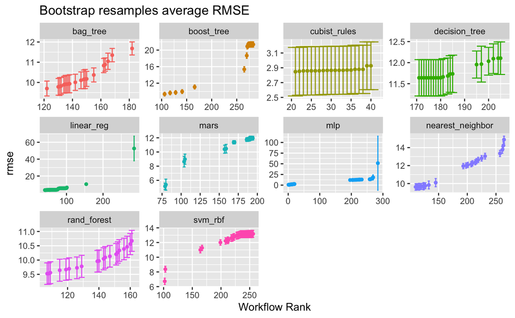

# Model Results on test set

| .metric | .estimator | .estimate | .config |
| --- | --- | --- | --- |
| rmse | standard | 0.7274025 | Preprocessor1_Model1 |
| rsq | standard | 0.9968596 | Preprocessor1_Model1 |